# Association of latent factors to time to next treatment

Britta Velten

16 March, 2018

# 1 Introduction

This script analyses the links of the MOFA factors to clinical outcome as shown in Figure 5 of the manuscript. The analysis is based on the model and other objects defined in import_models.Rmd.

```r
library(MOFAtools)
library(dplyr)
library(reshape2)
library(pheatmap)
library(survival)
library(gridExtra)
library(ggplot2)
library(GGally)
library(magrittr)
library(Hmisc)
library(glmnet)
library(cowplot)
```

# 2 I/O options

```r
#output path for plots and data
plotdir <- "figures/survival/"
if(!dir.exists(plotdir)) dir.create(plotdir)
knitr::opts_chunk$set(fig.path=plotdir, dev=c("png", "pdf"))
outdir <- "out"
```

# 3 Get fitted model and related data

(Prepared in import_models.Rmd)

```r
# load model selected in import_models.Rmd
load(file.path(outdir,"out_import.RData"))

# helper function for some plots
source("plotting_utils.R")
```

# 4 Get survival data from Dietrich et al. 2017

The patmeta and covariates objects are constucted in import_models.Rmd on the basis of the pace package.

```r
data(patmeta, package="pace")
survivalData <- as.matrix(patmeta[,c("T5","treatedAfter")])
survivalData<- survivalData[!is.na(survivalData[,1]),]
colnames(survivalData)<-c("time", "status")

# subset to common patients
commonPats <- intersect(rownames(Z), rownames(survivalData))
Zcommon <- Z[commonPats,]
survivalData <- survivalData[commonPats,]
covariatesCommon <- covariates[commonPats,]
dataCommmon <- lapply(data, function(dd) dd[,commonPats])

# construct survival object
SurvObject <-Surv(survivalData[,1],survivalData[,2])
```

# 5 Fit univariate Cox models for each factor

All covariates are scaled to ensure comparability of hazard ratio.This, however, looses interpretability of HR for 0-1 groups.

```r
# fit a cox model for latent factors, scaling predictors
pval_LFs<-sapply(which(apply(Z,2,var, na.rm=T)>0), function(i){
    fit <- coxph(SurvObject  ~  scale(Zcommon[,i]))
    s <- summary(fit)
    c(p      = s[["coefficients"]][, "Pr(>|z|)"],
      coef   = s[["coefficients"]][, "exp(coef)"],
      lower  = s[["conf.int"]][, "lower .95"],
      higher = s[["conf.int"]][, "upper .95"])
  })
colnames(pval_LFs) <- colnames(Z)[which(apply(Z,2,var, na.rm=T)>0)]

# collect in data frame
df_survival <- as.data.frame(t(pval_LFs))
df_survival$label <- paste(formatC(df_survival$p, digits = 2), sep="")
df_survival$predictor <- factor(paste("Factor",colnames(pval_LFs)), levels=rev(paste("Factor",colnames(pval_LFs))))
df_survival
```

```
##               p      coef     lower    higher   label predictor
## 1  2.623478e-05 0.6499277 0.5316406 0.7945330 2.6e-05  Factor 1
## 2  2.544566e-01 1.1407150 0.9095763 1.4305899    0.25  Factor 2
## 3  1.093300e-01 0.8489863 0.6948187 1.0373608    0.11  Factor 3
## 4  3.167230e-01 0.8902660 0.7090885 1.1177358    0.32  Factor 4
## 5  1.080130e-01 0.8565113 0.7090897 1.0345822    0.11  Factor 5
## 6  9.483115e-01 1.0065045 0.8273433 1.2244632    0.95  Factor 6
## 7  9.064477e-07 1.6178737 1.3352247 1.9603558 9.1e-07  Factor 7
## 8  1.538915e-09 0.4464297 0.3436397 0.5799665 1.5e-09  Factor 8
## 9  7.411497e-02 0.8336785 0.6828062 1.0178875   0.074  Factor 9
## 10 4.215315e-03 0.7350997 0.5953930 0.9075881  0.0042 Factor 10
```

```r
# re-orient to HR > 1
df_survival %<>% mutate(positive = coef>1)
df_survival %<>% mutate(y = ifelse(positive,coef, 1/coef))
df_survival %<>% mutate(ymin = ifelse(positive,lower, 1/lower))
df_survival %<>% mutate(ymax = ifelse(positive,higher, 1/higher))
```

## 5.1 Forest Plot

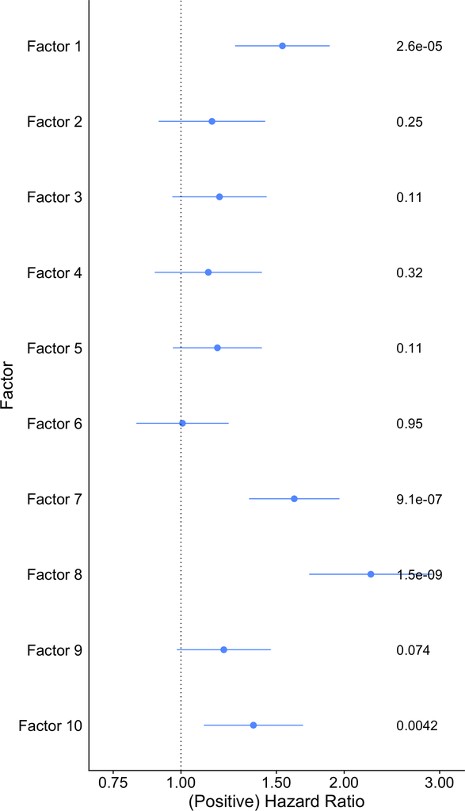

```r
# TTT
ggplot(df_survival, aes(x=predictor, y=y,ymin=ymin,ymax=ymax))+
  geom_pointrange( col='#619CFF')+ coord_flip() +
  scale_x_discrete() + ylab("(Positive) Hazard Ratio")+
  scale_y_log10(breaks=c(0.75,1,1.5,2,3), limits=c(min(df_survival$ymin)-0.1,3.1)) +
  geom_hline(aes(yintercept=1), linetype="dotted") +
  geom_text(aes(label=label, y=2.5),size=5, hjust = "left")+
  theme(text =element_text(size=18),
        axis.ticks.y = element_blank(),
        legend.position="bottom", panel.grid =element_blank(),
        panel.background = element_rect(fill="white"),
        strip.text = element_blank(),
        axis.text.y = element_text(size=16),
        axis.text.x = element_text(size=16),
        plot.title = element_text(size=18)) +
  guides(colour=F) +
  xlab("Factor") + scale_color_discrete(drop=FALSE)
```

# 6 Multivariate models for predicting survival

Harrals C-Index is used as performance measure, 5-fold stratified cross-validation. Both models using PCs and no penalization as well as using all features with a ridge approach are fitted here.

```r
  #stratified CV to include same proportion of uncensored cases
  set.seed(1290)
  uncensored <- SurvObject[,"status"]==1
  cv_ix <- dismo::kfold(1:length(commonPats), k=5, by=uncensored)

  # Use same number of principal components as predictors as MOFA factors (without the intercept)
  topPC <- ncol(Z) - 1

  # impute missing data values by mean
  data_imputed <- lapply(dataCommmon, function(view) {
    apply(view,1, function(x) { x[is.na(x)] <- mean(x, na.rm=TRUE); return(x)})
  })

  # add concatenated data matrix
  data_imputed$all <- Reduce(cbind, data_imputed)

  # construct predictor list fo first 'topPC' PCs each
  FeatureList <- lapply(names(data_imputed), function(singleview){
    dat <- data_imputed[[singleview]]
    pc.out <- prcomp(dat)
    pc.out$x[,1:topPC]
  })
  names(FeatureList) <- paste(names(data_imputed),sep="")
  names(FeatureList)[grep("viab",names(FeatureList))] <- "DrugResponse"

  # add MOFA factors
  FeatureList$LF = Zcommon[,-1]

  # List of predictors using all features
  FeatureList_all <- data_imputed
  names(FeatureList_all) <- paste(names(data_imputed),"full",sep="_")

  # fit a cox model and predict on left-out fold
  fit <- lapply(unique(cv_ix), function(i){

  #fit coxph for reduced (i.e. MOFA facotrs and PCs)
  c = lapply(FeatureList, function(x) coxph(SurvObject[cv_ix!=i,]  ~ as.matrix(x)[cv_ix!=i,]))
  p = mapply(function(x,y) as.matrix(x[cv_ix==i,]) %*% coef(y), FeatureList, c)

  # fit cox model with ridge penalty for all
  c_all = lapply(FeatureList_all, function(x)
  cv.glmnet(as.matrix(x)[cv_ix!=i,], survivalData[cv_ix!=i,], family="cox", alpha=0))
  p_all = mapply(function(x,y) as.matrix(x[cv_ix==i,]) %*% coef(y, y$lambda.min), FeatureList_all, c_all)
  p_all <- do.call(cbind, p_all)
  colnames(p_all) <- names(FeatureList_all)

  # calculate CI    on left-out fold
  p_joint <- cbind(p, p_all)
  CI=apply(-p_joint,2, rcorr.cens, SurvObject[cv_ix==i])[1,]
  list(CI=CI,c=c, c_all=c_all)
  })

  # get cross-validated CI
  concordanceCV <- sapply(fit, function(l) l$CI)
  colnames(concordanceCV) <- unique(cv_ix)
  df_hc <- melt(concordanceCV, varnames = c("predictor", "cv_idx"), value.name = "CI")
  df_hc$predictor <- ifelse(df_hc$predictor=="LF", "MOFA factors", as.character(df_hc$predictor))

  # calculate summary statistics across folds
  summaryHc <- aggregate(df_hc$CI,
    by = list(predictors = df_hc$predictor),
    FUN = function(x) c(mean = mean(x), sd = sd(x),
                        n = length(x)))
  summaryHc <- do.call(data.frame, summaryHc)
  summaryHc$se <- summaryHc$x.sd / sqrt(summaryHc$x.n)

  summaryHc
```

```
##          predictors    x.mean       x.sd x.n          se
## 1               all 0.7409447 0.03234065   5 0.014463178
## 2          all_full 0.7430823 0.03650672   5 0.016326299
## 3             Drugs 0.6884616 0.06257370   5 0.027983810
## 4        Drugs_full 0.7102080 0.04400252   5 0.019678524
## 5       Methylation 0.7195992 0.01573335   5 0.007036167
## 6  Methylation_full 0.6941073 0.04752903   5 0.021255629
## 7      MOFA factors 0.7660704 0.06964864   5 0.031147819
## 8              mRNA 0.7148240 0.02933528   5 0.013119135
## 9         mRNA_full 0.7203712 0.03745143   5 0.016748789
## 10        Mutations 0.6938605 0.03800959   5 0.016998407
## 11   Mutations_full 0.6918274 0.08543174   5 0.038206234
```

## 6.1 Define colors for barplot

```r
cols4survival <- c("#E69F00","#D55E00","#009E73", "#56B4E9",  "#999999","#0072B2")
names(cols4survival) <- c("Methylation", "Mutations","mRNA",  "Drugs", "all", "MOFA factors")
```

Plot the resulting prediciton performance when principal componenets are included as predictors in a multivariate Cox model.

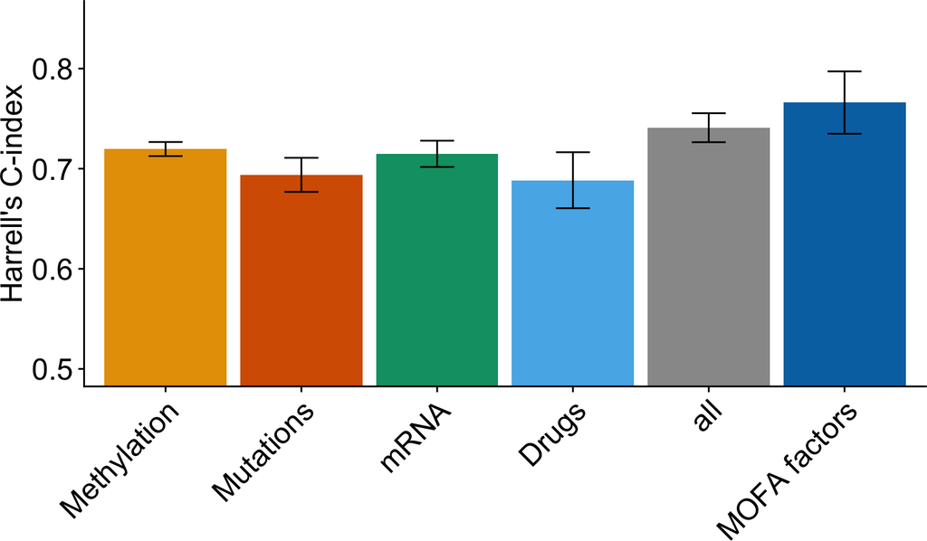

```r
summaryHc_main <- filter(summaryHc,
                         predictors %in% c(names(data), "all", "MOFA factors"))
limits <- aes(ymax = summaryHc_main$x.mean + summaryHc_main$se,
              ymin = summaryHc_main$x.mean - summaryHc_main$se)
summaryHc_main$predictors <- factor(summaryHc_main$predictors,
                                    levels =c("Methylation", "Mutations","mRNA",  "Drugs",
                                               "all", "MOFA factors"))

# barplot
  ggplot(summaryHc_main, aes(x=predictors, y=x.mean, fill=predictors, group=predictors))+
    geom_bar(stat = "identity") +
   coord_cartesian(ylim = c(0.5,0.85)) +
  scale_fill_manual(values=cols4survival, labels=names(cols4survival)) +
  geom_errorbar(limits, position = "dodge", width = 0.25)+
  theme(axis.text.x = element_text(angle = 45, hjust = 1, size=18),
        axis.text.y = element_text(size=18),
         axis.title.y = element_text(size=18),
        strip.background = element_rect(fill="white"),
        strip.text = element_blank(),
        legend.position= "none",
        plot.title = element_text(size=20)) +
  ylab("Harrell's C-index") + xlab("")
```

## 6.3 Supplement S14: All features as predictors

Plot the resulting prediciton performance when all features are included as predictors in a multivariate Cox model with ridge penalty.

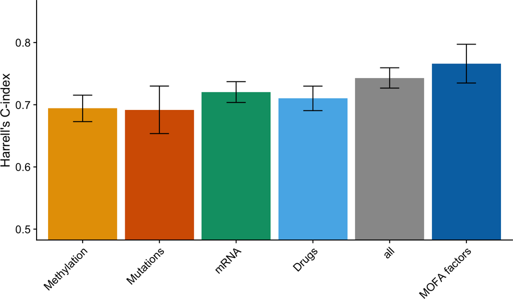

```r
summaryHc_supp <- filter(summaryHc,
                         predictors %in% c(paste(c(names(data), "all"), "full", sep="_"), "MOFA factors"))#, "factors 1,7,8"))
limits <- aes(ymax = summaryHc_supp$x.mean + summaryHc_supp$se,
              ymin = summaryHc_supp$x.mean - summaryHc_supp$se)
summaryHc_supp$predictors <- factor(sapply(summaryHc_supp$predictors, function(nm) sub("_full","",nm)),
                                    levels =c("Methylation", "Mutations","mRNA",  "Drugs",
                                               "all", "MOFA factors"))

# barplot
  ggplot(summaryHc_supp, aes(x=predictors, y=x.mean, fill=predictors, group=predictors))+
    geom_bar(stat = "identity") +
   coord_cartesian(ylim = c(0.5,0.85)) +
  scale_fill_manual(values=cols4survival, labels=names(cols4survival)) +
  geom_errorbar(limits, position = "dodge", width = 0.25)+
  theme(axis.text.x = element_text(angle = 45, hjust = 1),
        strip.background = element_rect(fill="white"),
        strip.text = element_blank(),
        legend.position= "none",
        plot.title = element_text(size=20)) +
  ylab("Harrell's C-index") + xlab("")
```

# 7 Kaplan-Meier plots

To visualize the association of the factor to clinical outcome. Samples are split into two groups based on the continious factors and a Kaplan Meier plot is made for those groups. Note that this is mainly for visualisation purposes, usually the continious factor should be considered as above in the Cox models.

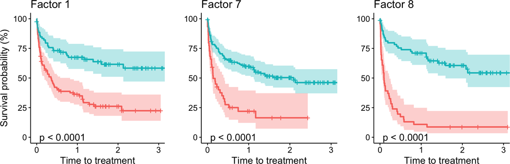

```r
  # calculate KM for all LFs
  glist <- lapply(as.character(1:(ncol(Z)-1)), function(lfno){

  #determine optimal cut-point and classify samples accordingly
  df <- data.frame(time=survivalData[,1], event = survivalData[,2], Zcommon)
  cut <- survminer::surv_cutpoint(df, variables=paste("X", lfno, sep=""))
  df$FactorCluster <- Zcommon[,lfno] > cut$cutpoint$cutpoint

  # due to rotational invariance of factors just use same colors for upper and lower group in the KM plot
  # (irrescpecitve of which end of the factor they belong to)
  if(lfno==7) df$FactorCluster <- Zcommon[,lfno] < cut$cutpoint$cutpoint

  # fit survival model for the given factor
  fit <- survfit(Surv(time, event) ~ FactorCluster, df)
  ggLF <- survminer::ggsurvplot(fit, data =df,
                        conf.int = TRUE,
                        pval = TRUE,
                        fun = function(y) y*100,
                        legend = "none",
                        legend.labs = c(paste("low LF", lfno), paste("high LF", lfno)),
                        xlab = "Time to treatment",
                        ylab=ifelse(lfno==1, "Survival probability (%)", ""),
                        title= paste("Factor", lfno)
                        )
  ggLF$plot
 })

 # make joint plot of significant factors:
    grid.arrange(glist[[1]], glist[[7]], glist[[8]], ncol=3)
```

# 8 Connections to clinical covariates

## 8.1 Load clinical covariates

```r
covariates_mofa <- covariates

# Get patient IDs transaltion form P to H numbers
load("~/Documents/cll/var/encPatientID_160218.RData")
rownames(encPatientID) <- encPatientID$PatientID

# doubling times (only available for 90 patients)
load("~/Documents/CLL/OtherData/DoublingTime_070816.RData")
LDT <- as.data.frame(LDT)
rownames(LDT) <- LDT$patID
rownames(LDT) <- encPatientID[rownames(LDT),]$PatientID2
doublingtimes <- LDT[rownames(Z),]$doubling.time

# Add Mutations and LDT to covariates
covariates <- cbind(covariates_mofa[rownames(Z),],
                    t(model@TrainData$Mutations)[rownames(Z),!colnames(t(model@TrainData$Mutations))%in% colnames(covariates_mofa)],
                    doubling.times =doublingtimes)

# Clinical markers to compare
biomarkers <- c("IGHV", "TP53", "age", "sex",
                "MethylationCluster",
                 "pretreated",
                 "doubling times")

# numeric code for IGHV and MC
covariates[,"IGHV"] <- ifelse(covariates[,"IGHV"]=="U",0,1)
covariates[,"MethylationCluster"] <- ifelse(covariates[,"MethylationCluster"]=="LP",0,
                                            ifelse(covariates[,"MethylationCluster"]=="IP",0.5,1))

#nice names
colnames(covariates) <- sapply(colnames(covariates), function(s) ifelse(s=="IC50beforeTreatment","pretreated",s) )
colnames(covariates) <- sapply(colnames(covariates), function(s) ifelse(s=="doubling.times","doubling times",s) )

# get biomarkers
all(biomarkers %in% colnames(covariates))
```

```
## [1] TRUE
```

```r
covariates <- covariates[,biomarkers]
```

## 8.2 Marginal Cox models

All covariates are scaled to ensure comparability of hazard ratio.This, however, looses interpretability of HR for 0-1 groups.

```r
  # subset to patients having the clinical markers
  commonPats <- intersect(commonPats, rownames(covariates)[!apply(covariates,1, function(pat) any(is.na(pat)))])
  print(length(commonPats))
```

```
## [1] 76
```

```r
  print(paste("uncensored:",sum(survivalData[,2])))
```

```
## [1] "uncensored: 96"
```

```r
  Zcommon <- Z[commonPats,]
  covariatesCommon <- covariates[commonPats,]
  survivalData <- survivalData[commonPats,]

  # construct survival object
  SurvObject <-Surv(survivalData[,1],survivalData[,2])

  # fit a cox model for latent factors, scaling predictors
  pval_LFs <- sapply(which(apply(Z,2,var, na.rm=T)>0), function(i){
    fit <- coxph(SurvObject  ~  scale(Zcommon[,i]))
    s <- summary(fit)
    c(p      = s[["coefficients"]][, "Pr(>|z|)"],
      coef   = s[["coefficients"]][, "exp(coef)"],
      lower  = s[["conf.int"]][, "lower .95"],
      higher = s[["conf.int"]][, "upper .95"])
  })
  colnames(pval_LFs) <- paste("Factor",colnames(Z)[which(apply(Z,2,var, na.rm=T)>0)])

  # fit a cox model for other relevant biomarkers, scaling all predictor
  pvals_Cov<-sapply(biomarkers, function(cnm){
    fit <- coxph(SurvObject  ~  scale(covariatesCommon[,cnm]))
    s <- summary(fit)
    c(p      = s[["coefficients"]][, "Pr(>|z|)"],
      coef   = s[["coefficients"]][, "exp(coef)"],
      lower  = s[["conf.int"]][, "lower .95"],
      higher = s[["conf.int"]][, "upper .95"])
  })

  # collect in data frame
  pvalsSurv<-cbind(pval_LFs,pvals_Cov)
  df_surv <- as.data.frame(t(pvalsSurv))
  df_surv$predictor <- rownames(df_surv)
  types <- list(latentFactors = colnames(pval_LFs),
                mutations = biomarkers[biomarkers%in% rownames(model@TrainData$Mutations)],
                demographics  = biomarkers[grepl("sex|age", biomarkers)],
                clinical = biomarkers[grepl("doubling|pretreated", biomarkers)],
                other = biomarkers[grepl("MethylationCluster", biomarkers)])

  df_surv$predictorType <- with(df_surv, ifelse(predictor %in% types$latentFactors, "MOFA factors",
                              ifelse(predictor %in% types$mutations, "genetic",
                                     ifelse(predictor %in% types$clinical, "clinical",
                                            ifelse(predictor %in% types$demographics, "demographic", "other")))))
  df_surv$predictor <- factor(df_surv$predictor, levels = rev(Reduce(c, types)))
  df_surv$survType <- "Time to next treatment"
  df_surv$label <- paste(formatC(df_surv$p, digits = 2), sep="")
  df_surv
```

```
##                               p      coef     lower    higher
## Factor 1           7.005689e-03 0.6696185 0.5003026 0.8962355
## Factor 2           4.244708e-01 1.1446406 0.8216681 1.5945639
## Factor 3           1.722743e-01 0.8148524 0.6072864 1.0933631
## Factor 4           4.927159e-01 0.9040884 0.6777987 1.2059272
## Factor 5           7.012740e-02 0.7865998 0.6066501 1.0199277
## Factor 6           1.997336e-01 0.8330171 0.6300521 1.1013654
## Factor 7           2.846530e-05 2.0098449 1.4494261 2.7869488
## Factor 8           1.999290e-06 0.4485379 0.3222766 0.6242657
## Factor 9           5.485624e-01 0.9085441 0.6641403 1.2428888
## Factor 10          3.144795e-01 0.8404513 0.5989946 1.1792400
## IGHV               7.240630e-04 0.5857548 0.4295690 0.7987275
## TP53               1.834619e-04 1.6726171 1.2774634 2.1900025
## age                2.644475e-01 0.8507683 0.6405258 1.1300198
## sex                6.071176e-01 0.9262417 0.6916500 1.2404016
## MethylationCluster 2.771869e-03 0.6218042 0.4554925 0.8488405
## pretreated         7.608825e-09 0.4007105 0.2938196 0.5464880
## doubling times     1.362166e-11 0.2413446 0.1598424 0.3644040
##                             predictor predictorType               survType
## Factor 1                     Factor 1  MOFA factors Time to next treatment
## Factor 2                     Factor 2  MOFA factors Time to next treatment
## Factor 3                     Factor 3  MOFA factors Time to next treatment
## Factor 4                     Factor 4  MOFA factors Time to next treatment
## Factor 5                     Factor 5  MOFA factors Time to next treatment
## Factor 6                     Factor 6  MOFA factors Time to next treatment
## Factor 7                     Factor 7  MOFA factors Time to next treatment
## Factor 8                     Factor 8  MOFA factors Time to next treatment
## Factor 9                     Factor 9  MOFA factors Time to next treatment
## Factor 10                   Factor 10  MOFA factors Time to next treatment
## IGHV                             IGHV       genetic Time to next treatment
## TP53                             TP53       genetic Time to next treatment
## age                               age   demographic Time to next treatment
## sex                               sex   demographic Time to next treatment
## MethylationCluster MethylationCluster         other Time to next treatment
## pretreated                 pretreated      clinical Time to next treatment
## doubling times         doubling times      clinical Time to next treatment
##                      label
## Factor 1             0.007
## Factor 2              0.42
## Factor 3              0.17
## Factor 4              0.49
## Factor 5              0.07
## Factor 6               0.2
## Factor 7           2.8e-05
## Factor 8             2e-06
## Factor 9              0.55
## Factor 10             0.31
## IGHV               0.00072
## TP53               0.00018
## age                   0.26
## sex                   0.61
## MethylationCluster  0.0028
## pretreated         7.6e-09
## doubling times     1.4e-11
```

Make Forest plot

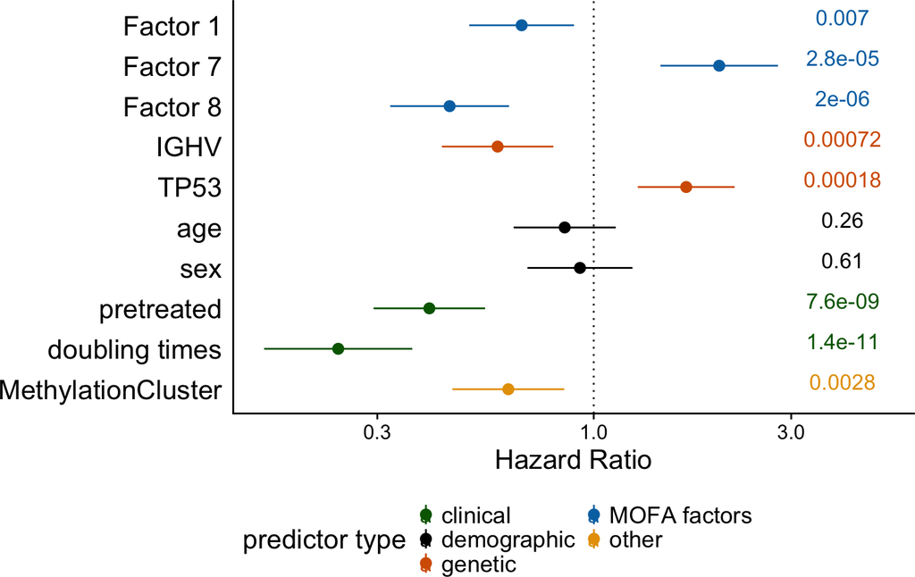

```r
col4Types <- c(cols4survival["MOFA factors"], cols4survival["Mutations"],
              "black", "darkgreen", cols4survival["Methylation"])
names(col4Types) <- c('MOFA factors', "genetic", "demographic", "clinical", "other")
gg_forest <- ggplot(filter(df_surv, !predictor %in% paste("Factor",1:10)| p < 0.01), aes(x=predictor,y=coef,ymin=lower,ymax=higher, col=predictorType))+
  geom_pointrange()+ coord_flip() +
  scale_x_discrete() + ylab("Hazard Ratio")+
  scale_y_log10(breaks=c(0.1,0.3,1,3), limits=c(min(df_surv$lower),5)) +
  geom_hline(aes(yintercept=1), linetype="dotted") + facet_wrap(~survType) +
  geom_text(aes(label=label, y=4),size=4.5, vjust = 0)+
  theme(text =element_text(size=16),
        axis.ticks.y = element_blank(),
        legend.position="bottom", panel.grid =element_blank(),
        panel.background = element_rect(fill="white"),
        strip.text = element_blank(),
        axis.text.y = element_text(size=16),
        plot.title = element_text(size=18)) +
  guides(colour=guide_legend("predictor type", ncol=2)) +
  xlab("") + scale_color_manual(values=col4Types)
gg_forest
```

## 8.3 C-Index

Harrals C-Index is used as performance measure, 5-fold stratified cross-validation.

```r
  #stratified CV to include same proportion of uncensored cases
  set.seed(1290)
  uncensored <- SurvObject[,"status"]==1
  cv_ix <- dismo::kfold(1:length(commonPats), k=5, by=uncensored)

  # add covariates from forest plot
  FeatureList <- list()
  FeatureList$factors = Zcommon[,c("1","7","8")]
  FeatureList$clinical <- covariatesCommon[colnames(covariatesCommon) %in% types$clinical]
  FeatureList$demographic <- covariatesCommon[colnames(covariatesCommon) %in% types$demographics]
  FeatureList$other <- covariatesCommon[colnames(covariatesCommon) %in% types$other]
  FeatureList$genetic <- covariatesCommon[colnames(covariatesCommon) %in% types$mutations]

  # fit a cox model and predict on left-out fold
  fit <- lapply(unique(cv_ix), function(i){
      c = lapply(FeatureList, function(x) coxph(SurvObject[cv_ix!=i,]  ~ as.matrix(x)[cv_ix!=i,]))
      p = mapply(function(x,y) as.matrix(x[cv_ix==i,]) %*% coef(y), FeatureList, c)
      CI=apply(-p,2, rcorr.cens, SurvObject[cv_ix==i])[1,]
      list(CI=CI,c=c)
  })

    # get cross-validated CI
    concordanceCV <- sapply(fit, function(l) l$CI)
    colnames(concordanceCV) <- unique(cv_ix)
    df_hc <- melt(concordanceCV, varnames = c("predictor", "cv_idx"), value.name = "CI")
    df_hc$survType <-"Time to next treatment"
    df_hc$predictor <- ifelse(df_hc$predictor=="factors", "MOFA factors", as.character(df_hc$predictor))
    df_hc
```

```
##       predictor cv_idx        CI               survType
## 1  MOFA factors      3 0.7142857 Time to next treatment
## 2      clinical      3 0.7142857 Time to next treatment
## 3   demographic      3 0.6476190 Time to next treatment
## 4         other      3 0.4809524 Time to next treatment
## 5       genetic      3 0.5571429 Time to next treatment
## 6  MOFA factors      4 0.8135593 Time to next treatment
## 7      clinical      4 0.7529412 Time to next treatment
## 8   demographic      4 0.6235294 Time to next treatment
## 9         other      4 0.6764706 Time to next treatment
## 10      genetic      4 0.6941176 Time to next treatment
## 11 MOFA factors      5 0.8674699 Time to next treatment
## 12     clinical      5 0.8313253 Time to next treatment
## 13  demographic      5 0.5060241 Time to next treatment
## 14        other      5 0.6144578 Time to next treatment
## 15      genetic      5 0.6506024 Time to next treatment
## 16 MOFA factors      2 0.7594937 Time to next treatment
## 17     clinical      2 0.8604651 Time to next treatment
## 18  demographic      2 0.6395349 Time to next treatment
## 19        other      2 0.6453488 Time to next treatment
## 20      genetic      2 0.7906977 Time to next treatment
## 21 MOFA factors      1 0.7865169 Time to next treatment
## 22     clinical      1 0.7865169 Time to next treatment
## 23  demographic      1 0.3370787 Time to next treatment
## 24        other      1 0.7808989 Time to next treatment
## 25      genetic      1 0.8370787 Time to next treatment
```

```r
# calculate summary statistics across folds
summaryHc <- aggregate(df_hc$CI,
    by = list(predictors = df_hc$predictor, survType=df_hc$survType),
    FUN = function(x) c(mean = mean(x), sd = sd(x),
                        n = length(x)))
summaryHc <- do.call(data.frame, summaryHc)
summaryHc$se <- summaryHc$x.sd / sqrt(summaryHc$x.n)

summaryHc
```

```
##     predictors               survType    x.mean       x.sd x.n         se
## 1     clinical Time to next treatment 0.7891068 0.05870959   5 0.02625573
## 2  demographic Time to next treatment 0.5507572 0.13249440   5 0.05925330
## 3      genetic Time to next treatment 0.7059278 0.11149419   5 0.04986172
## 4 MOFA factors Time to next treatment 0.7882651 0.05748260   5 0.02570700
## 5        other Time to next treatment 0.6396257 0.10858068   5 0.04855876
```

Make barplot

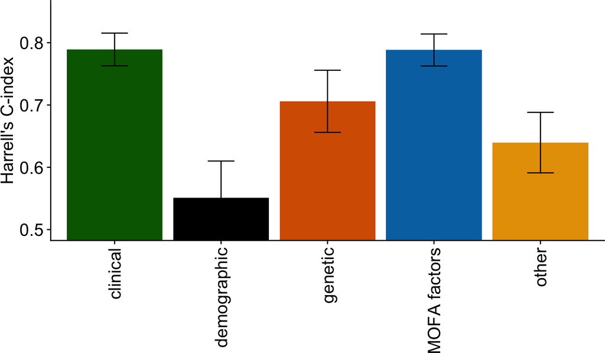

```r
limits <- aes(ymax = summaryHc$x.mean + summaryHc$se,
              ymin = summaryHc$x.mean - summaryHc$se)

# barplot
  gg_bar <- ggplot(summaryHc, aes(x=predictors, y=x.mean, fill=predictors, group=predictors))+
    geom_bar(stat = "identity") +
   coord_cartesian(ylim = c(0.5,0.85)) +
  # ggtitle(paste("Prediction of time to treatment"))+
  scale_fill_manual(values=col4Types) +
  geom_errorbar(limits, position = "dodge", width = 0.25)+
  theme(axis.text.x = element_text(angle = 90, vjust=0.5,hjust = 1, size=16, lineheight=-2),
        axis.text.y = element_text(size=16),
         axis.title.y = element_text(size=16),
        strip.background = element_rect(fill="white"),
        strip.text = element_blank(),
        legend.position= "none",
        plot.title = element_text(size=18)) +
  ylab("Harrell's C-index") + xlab("")
gg_bar
```

## 8.4 Arrange plots

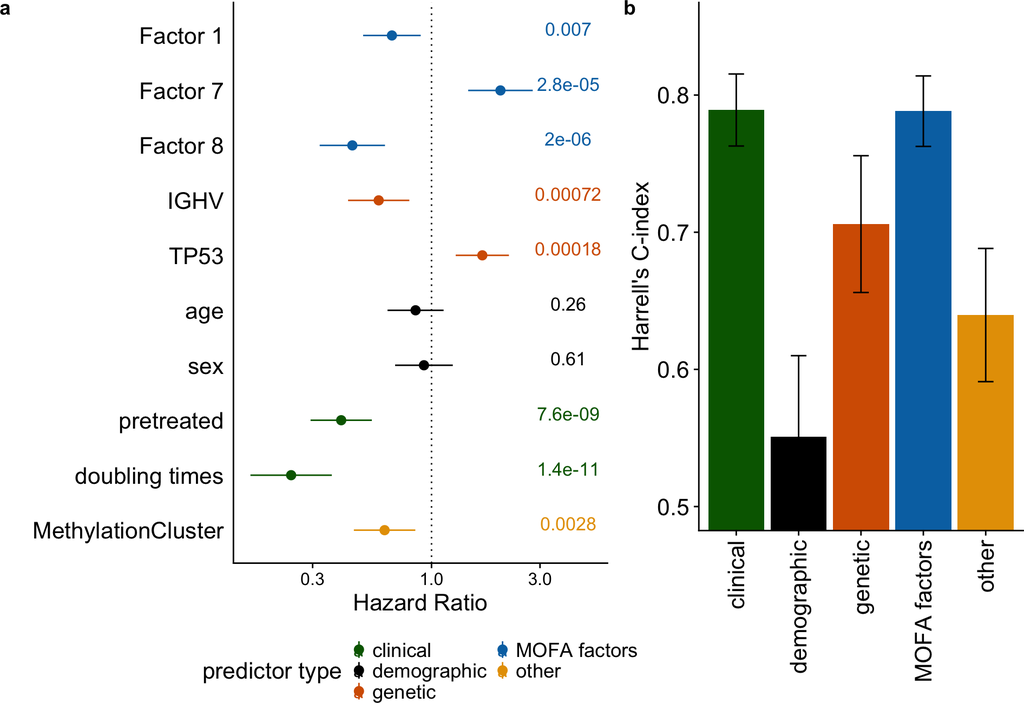

```r
plot_grid(gg_forest, gg_bar, labels = c("a","b"), rel_widths=c(1.5,1))
```